# Homework 3

BIOF 439, Spring 2019

Due Tuesday, April 30

We’re going to play with the dataset `mpg` (found in the `ggplot2` package). To access this dataset, you first will have to activate `ggplot2`. You’ll also need the `ggpubr` package.

Try and make your plots close to publication quality, in that all the writing on the graph should be proper English rather than variable names. This might include axis labels, legend titles and legend levels. Ensure each plot has a title. Save each file as a PNG file as well, using code (just on RStudio Cloud). You may need to change (mutate) the data to do this, especially for labels.

I know you’ll be using some data manipulation techniques that we covered rather quickly, so please use the R Help, the RStudio cheatsheets and any other resources you find (just state what you used). That’s part of my reality as well, when I want to do something that I’m not really sure how to do.

### Some possibly useful material

1. Each of the verbs `mutate`, `arrange`, `filter` and `summarize` have *scoped* versions: `*_all`. `*_at` and `*_if`.

   > The variants suffixed with _if, _at or _all apply an expression (sometimes several) to all variables within a specified subset. This subset can contain all variables (_all variants), a vars() selection (_at variants), or variables selected with a predicate (_if variants).
2. You should create your own theme for all of the plots in this assignment. The way you do this is using the following template (take out or add in elements):

```r
my_theme <- function(){
  theme_bw() +
    theme(axis.title = element_text(size = 14))
}
```

Look at the documentation for `theme` (using `?theme`) . There are nice descriptions [here](https://bookdown.org/rdpeng/RProgDA/building-a-new-theme.html) and [here](https://www.datanovia.com/en/blog/ggplot-themes-gallery/). You can also choose something from the `ggthemes` package (which you may need to install).

### Questions

**Question 1:** Let’s start by creating some summaries from this data. We will use the function `summarize` from the tidyverse.

1. Find the average efficiencies for each manufacturer, separately for city and highway

```r
library(tidyverse)
mpg %>%
  group_by(manufacturer) %>%
  summarize_at(vars(cty, hwy), mean)
```

```
## # A tibble: 15 x 3
##    manufacturer   cty   hwy
##    <chr>        <dbl> <dbl>
##  1 audi          17.6  26.4
##  2 chevrolet     15    21.9
##  3 dodge         13.1  17.9
##  4 ford          14    19.4
##  5 honda         24.4  32.6
##  6 hyundai       18.6  26.9
##  7 jeep          13.5  17.6
##  8 land rover    11.5  16.5
##  9 lincoln       11.3  17
## 10 mercury       13.2  18
## 11 nissan        18.1  24.6
## 12 pontiac       17    26.4
## 13 subaru        19.3  25.6
## 14 toyota        18.5  24.9
## 15 volkswagen    20.9  29.2
```

2. Compute the average efficiencies by manufacturer and year

```r
mpg %>%
  group_by(manufacturer, year) %>%
  summarize_at(vars(cty, hwy), mean)
```

```
## # A tibble: 30 x 4
## # Groups:   manufacturer [15]
##    manufacturer  year   cty   hwy
##    <chr>        <int> <dbl> <dbl>
##  1 audi          1999  17.1  26.1
##  2 audi          2008  18.1  26.8
##  3 chevrolet     1999  15.1  21.6
##  4 chevrolet     2008  14.9  22.1
##  5 dodge         1999  13.4  18.4
##  6 dodge         2008  13.0  17.6
##  7 ford          1999  13.9  18.6
##  8 ford          2008  14.1  20.5
##  9 honda         1999  24.8  31.6
## 10 honda         2008  24    33.8
## # … with 20 more rows
```

3. Create a frequency table of the different classes of vehicles by year

```r
mpg %>% count(class, year) %>%
  spread(year, n) # 1st argument goes to headers, 2nd becomes values
```

```
## # A tibble: 7 x 3
##   class      `1999` `2008`
##   <chr>       <int>  <int>
## 1 2seater         2      3
## 2 compact        25     22
## 3 midsize        20     21
## 4 minivan         6      5
## 5 pickup         16     17
## 6 subcompact     19     16
## 7 suv            29     33
```

**Question 2:** We’ll do some data munging on this dataset

1. Check the data types for each variable using the `str` or `glimpse` function. They both do roughly the same thing, but provide a different output format.

```r
# str(mpg)
glimpse(mpg)
```

```
## Observations: 234
## Variables: 11
## $ manufacturer <chr> "audi", "audi", "audi", "audi", "audi", "audi", "au…
## $ model        <chr> "a4", "a4", "a4", "a4", "a4", "a4", "a4", "a4 quatt…
## $ displ        <dbl> 1.8, 1.8, 2.0, 2.0, 2.8, 2.8, 3.1, 1.8, 1.8, 2.0, 2…
## $ year         <int> 1999, 1999, 2008, 2008, 1999, 1999, 2008, 1999, 199…
## $ cyl          <int> 4, 4, 4, 4, 6, 6, 6, 4, 4, 4, 4, 6, 6, 6, 6, 6, 6, …
## $ trans        <chr> "auto(l5)", "manual(m5)", "manual(m6)", "auto(av)",…
## $ drv          <chr> "f", "f", "f", "f", "f", "f", "f", "4", "4", "4", "…
## $ cty          <int> 18, 21, 20, 21, 16, 18, 18, 18, 16, 20, 19, 15, 17,…
## $ hwy          <int> 29, 29, 31, 30, 26, 26, 27, 26, 25, 28, 27, 25, 25,…
## $ fl           <chr> "p", "p", "p", "p", "p", "p", "p", "p", "p", "p", "…
## $ class        <chr> "compact", "compact", "compact", "compact", "compac…
```

2. We already saw that there are only 2 years in this dataset. So it will be useful to convert this into a `factor`, which is a type meant for categorical data. We’ll do it in place, i.e., change the original data rather than make a copy.

```r
mpg <- mpg %>%
  mutate(year = as.factor(year)) #reminder, we are changing a variable
```

3. Let’s change all the character variables to factors too.

```r
mpg <- mpg %>%
  mutate_if(is.character, as.factor) #if a column is a character, change to a factor
```

4. Create a new dataset from mpg, where all the efficiencies are in one column, and another column denotes whether the data comes from city or highway mileage. We’ll need these for some graphics later.

```r
mpg1 <- mpg %>%
  gather(location, mpg, cty, hwy)
```

**Question 3:** Let’s do some descriptive graphs

1. Draw a barplot of the frequencies of different classes of vehicles, with separate panels for 1999 and 2008.

```r
## Your code here


ggplot(mpg, aes(x = class)) +
  geom_bar() +
  facet_wrap( ~ year)

##
```

[output not shown]

2. Now change this so that you have one plot, with stacked bars and year denoted by color

```r
ggplot(mpg, aes(x = class )) +
  geom_bar(aes(group = year, fill = year))
```

[output not shown]

3. Change the above graph so that the bars aren’t stacked, but side-by-side

```r
ggplot(mpg, aes(x = class )) +
  geom_bar(aes(group = year, fill = year), position = "dodge")
```

[output not shown]

4. Change the graph so that each bar goes from 0 to 1, and the color represents the relative proportion of total cars in the class were available in 1999 and 2008. (look at the different `position` options in ggplot2)

```r
ggplot(mpg, aes(x = class )) +
  geom_bar(aes(group = year, fill = year), position = 'fill' )
```

[output not shown]

**Question 4:** Show the relationship between displacement (`displ`) and fuel efficiency in one plot. This should be a scatter plot with a smooth line, with colors representing city and highway. Make sure the levels in the legend are “city” and “highway” rather than “cty” and “hwy”. You’ll have to modify the data to do this. One way is suggested below.

*Hint:* This uses what I called one of my favorite or most used tricks in data manipulation.

```r
## Your code here. Naming choices for 1 and 2 are yours

mpg1 <- mpg %>%
  gather(location, mpg, cty, hwy) %>%  # Both of those are fill-in-the-blank
  mutate(location = ifelse( location == 'cty', 'city','highway'))

ggplot(mpg1, aes(x = displ, y = mpg)) +
  geom_point(aes(color = location))  +
  geom_smooth(aes(color = location), se = F)

##
```

[output not shown]

**Question 5:** Compare the distributions of city mpg between 1999 and 2008 by manufacturer using boxplots or violin plots and facets. Add an annotation showing the result of a statistical test seeing if there is a difference between the two years (Hint: use `ggpubr::stat_compare_means`)

```r
library(ggpubr)
```

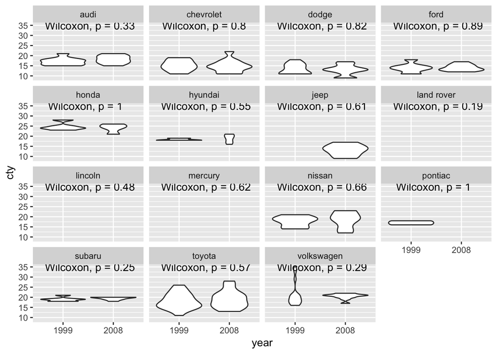

```r
ggplot(mpg, aes(x = year, y = cty)) +
  geom_violin() +
  facet_wrap(~manufacturer) +
  stat_compare_means()
```

## Challenge question

We want to see whether the difference between city and highway mileage within cars. We first create this plot, with one line per car. Note, to create this graph, you might have to create a new variable in your dataset.

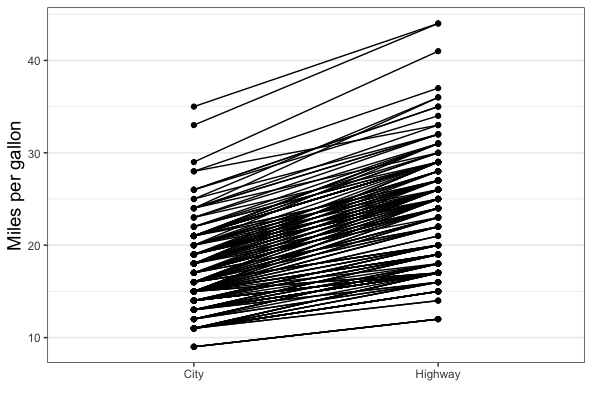

```r
knitr::include_graphics('img/line1.png')
```

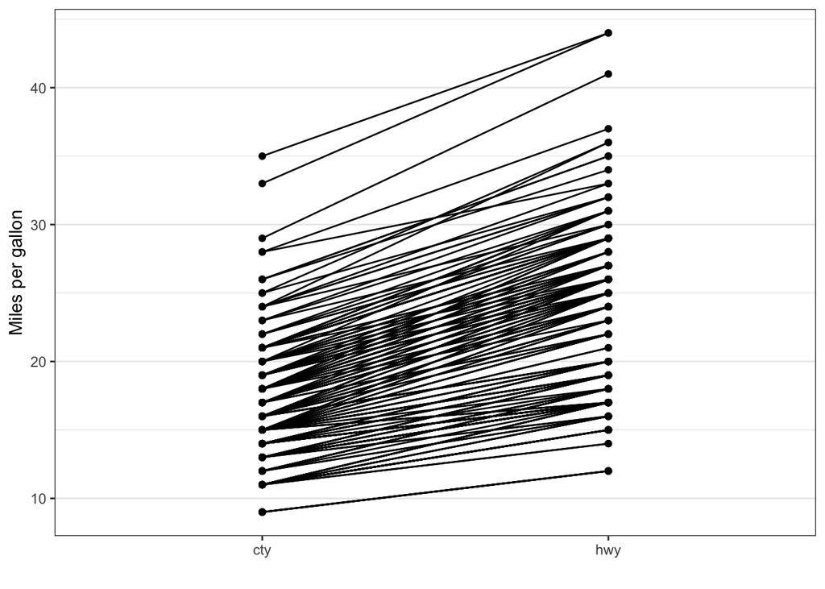

```r
mpg <- mpg %>% mutate(id = 1:n())
mpg1 <- mpg %>%
  gather(location, mpg, cty, hwy)
ggplot(mpg1, aes(x = location, y = mpg))+
  geom_point() +
  geom_line(aes(group = id)) +
  labs( x = '', y = 'Miles per gallon')+
  theme_bw() +
  theme(panel.grid.major.x = element_blank())
```

Let’s add some more depth to it. Color the lines and points by manufacturer.

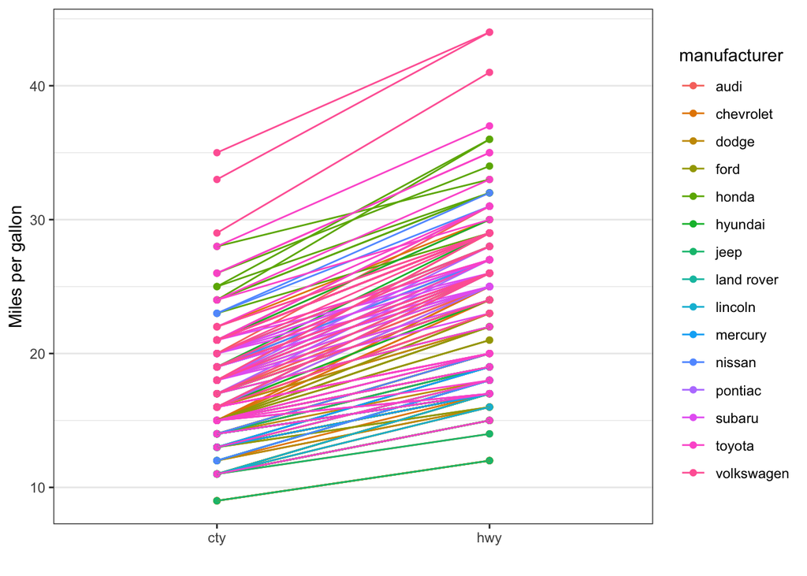

```r
ggplot(mpg1, aes(x = location, y = mpg, color = manufacturer))+
  geom_point() +
  geom_line(aes(group = id)) +
  labs( x = '', y = 'Miles per gallon')+
  theme_bw() +
  theme(panel.grid.major.x = element_blank())
```

This still seems rather messy, doesn’t it.

Let’s just use the data from 1999, and then create this plot with different facets for different manufacturers.

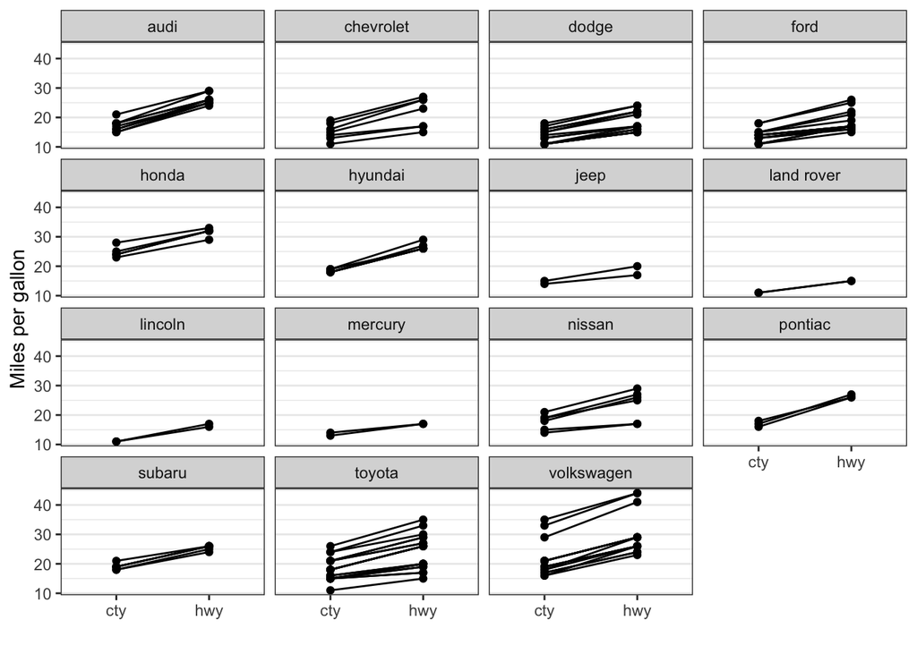

```r
mpg1 %>% filter(year == 1999) %>%
  ggplot(aes(x = location, y = mpg)) +
  geom_point() +
  geom_line(aes(group = id)) +
  facet_wrap( ~ manufacturer) +
  labs (x = '', y = 'Miles per gallon') +
  theme_bw() +
  theme (panel.grid.major.x = element_blank())
```